# Analysis of the tweets related to the brand Airbnb

Enas Alahmadi

December 18, 2017

# Introduction

In this report I analyze the tweets about the company Airbnb. Airbnb is the most tweeted brand in 2017, therefore it will be interesting to analyze the tweets associated with the brand. I here acquire the tweets from twitter using the package TwitterR and analyze the tweets. That is, I analyze the words associated with brand, and their frequencies. I also analyze the tweets sentiments.

# Installing required packages.

Before I start the analysis, I must install the packages needed.

Some of the libraries are not supported by CRAN so using install.packages() won’t work. We need to use the “devtools” package to install them from a url as shown below.

```r
 require(devtools)

  library(devtools)



# I saved the urls to the latest versions of the pakcages from CRAN archive
 rtem_url <- "https://cran.r-project.org/src/contrib/Archive/Rstem/Rstem_0.4-1.tar.gz"
 sentiment_url <- "https://cran.r-project.org/src/contrib/Archive/sentiment/sentiment_0.2.tar.gz"

#use devtools function install_url() to install the packages from the urls
install_url(rtem_url)
install_url(sentiment_url)
install.packages("Hmisc")
#load the libraries
library(Rstem)
library(sentiment)
```

```r
# Installing package if not already installed (Stanton 2013)
EnsurePackage<-function(x)
{x <- as.character(x)
 if (!require(x,character.only=TRUE))
 {
   install.packages(pkgs=x,repos="http://cran.r-project.org")
   require(x,character.only=TRUE)
 }
}



#Identifying packages required  (Stanton 2013)
PrepareTwitter<-function()
{
  EnsurePackage("twitteR")
  EnsurePackage("stringr")
  EnsurePackage("ROAuth")
  EnsurePackage("RCurl")
  EnsurePackage("ggplot2")
  EnsurePackage("reshape")
  EnsurePackage("tm")
  EnsurePackage("RJSONIO")
  EnsurePackage("wordcloud")
  EnsurePackage("gridExtra")
  EnsurePackage("plyr")
  EnsurePackage("leaflet")
  EnsurePackage("maps")
  library("Hmisc")
  library(ggplot2)
  library(Rstem)
  library(sentiment)
}

PrepareTwitter()
```

# Data Acquisition

The data is imported from Twitter. I created the function GetTweets in order to search twitter and save the results as a data frame. Meanwhile, the function GetTweetsFrequency calculate the frequency of each word mentioned in any of the tweets.

## Twitter Authentication

After installing the Packages, I authenticate access to twitter

```r
BRAND = "Airbnb"
#Function to Authenticate Access to Twitter
Authentication<-function() {
  # twitter auth vars
  BRAND = "Airbnb"
  CONSUMER_KEY="n0VQmi2OXrFQxoPvYvx2FIknI"
  CONSUMER_SECRET="hTkHfzJrIzQvpwAJLZAQYoyz3iryEEbX8gBlJloQedr51pNlRw"
  TOKEN="871919779426308099-Yn40D6rcq7zcC2qJowKB8aUvgSLpZVt"
  TOKEN_SECRET="aOBkoIl6wJXYcHMgstf9BuK3OapE5DNKMyr0sfycr3tQE"

  # twitter auth set-up
  setup_twitter_oauth(consumer_key=CONSUMER_KEY,
                      consumer_secret=CONSUMER_SECRET,
                      access_token=TOKEN,
                      access_secret=TOKEN_SECRET)
}

Authentication()
```

## Functions

```r
Search_Twitter <- function(key_word, n) {
  # contructing the search clause
  search_term <- paste0(key_word, ' OR ', key_word)

  # search twitter
  tweets <- searchTwitter(search_term, n=n, lang="en", retryOnRateLimit=2)

  # convert to a dataframe and return
  return (twListToDF(tweets))
}
```

```r
    GetFrequencyDataframe <- function(twts) {
      mach_corpus = Corpus(VectorSource(twts))

      # create document term matrix applying some transformations
      tdm = TermDocumentMatrix(mach_corpus,
                               control = list(removePunctuation = TRUE,
                                              removeNumbers = TRUE,
                                              stopwords = TRUE,
                                              wordLengths=c(3,Inf),
                                              tolower = TRUE))
      m = as.matrix(tdm)

      # get word counts in decreasing order
      word_freqs = sort(rowSums(m), decreasing=TRUE)

      # create a data frame with words and their frequencies
      dm = data.frame(words=names(word_freqs), freq=word_freqs, ordered = TRUE)
      return (dm)
    }
```

## Acuiring data

```r
# Twitter Search

# create a dataframe of the tweets using the BRAND name and n = number of tweets to search.
df_tweets = Search_Twitter(BRAND, 2000)

# create a data frame that measure the frequency of each word assosiated with the BRAND
fr = GetFrequencyDataframe(df_tweets)
```

# Cleaning the data

After I have acquired the data, I now clean it by removing the unused columns from the data frame, and by omitting any rows with a missing value.

## Cleaning the frequency data frame.

I reorder the frequency data frame, and remove the words with frequency of one. Hence, they have little to no significance in the analysis.

```r
# reordering the frequency col in fr.
fr = fr[with(fr, order(-freq)),]

# removing the words with frequency = 1
fr = fr[!fr$freq == 1,]


# clean fr from ("https", BRAND, "rt")
fr.clean = fr[!fr$word == "https",]
fr.clean = fr.clean[!fr.clean$word == BRAND,]
fr.clean = fr.clean[!fr.clean$word == "rt", ]
fr.clean = fr.clean[!fr.clean$word == "co", ]
fr.clean = fr.clean[!fr.clean$word == "com", ]
fr.clean = fr.clean[!fr.clean$word == "airbnb", ]
fr.clean = fr.clean[!fr.clean$word == "http", ]
```

## Cleaning the tweets data frame.

In this part I will be removing the unwanted columns and the rows with missing tweets. Since the number of the geocoded tweets is usually very low, I will divide the data frame into two; the first with the columns needed for analysis, and the second for the geocoded tweets. Then I will clean the data frames from missing values.

```r
#keeping only the needed columns of the tweets data frame
df_tweets.1 <- subset(df_tweets, select = c("text", "retweeted", "isRetweet"))

df_tweets.1 = na.omit(df_tweets.1) # removing the rows with missing values.

df_tweets.map = subset(df_tweets, select = c("longitude", "latitude"))
df_tweets.map = na.omit(df_tweets.map)
```

# Exploratory Data Analysis

## Descriptive statistics

### Analysis of the word frequency data frame

```r
The.mean = mean(fr.clean$freq)

The.mean
```

```
## [1] 18.24312
```

```r
Mode <- function(x) {
  ux <- unique(x)
  ux[which.max(tabulate(match(x, ux)))]
}

Mode(fr.clean$freq)
```

```
## [1] 2
```

```r
The.median = median(fr.clean$freq)
The.median
```

```
## [1] 3
```

```r
The.quantile = quantile(fr.clean$freq, c(0.05,0.1,0.25,0.5,0.75,0.9,0.95))
The.quantile
```

```
##  5% 10% 25% 50% 75% 90% 95%
##   2   2   2   3   6  13  25
```

```r
minimum.value = min(fr.clean$freq)
minimum.value
```

```
## [1] 2
```

```r
maximum.value = max(fr.clean$freq)
maximum.value
```

```
## [1] 6654
```

```r
range.freq = maximum.value - minimum.value
range.freq
```

```
## [1] 6652
```

```r
standard.deviation = sd(fr.clean$freq)
standard.deviation
```

```
## [1] 184.5593
```

### Histogram.

The Histogram represent the distribution of the frequencies of the words associated with the brand. The histogram is a visual tool which, infer the same conclusion from the values of the descriptive statistics.

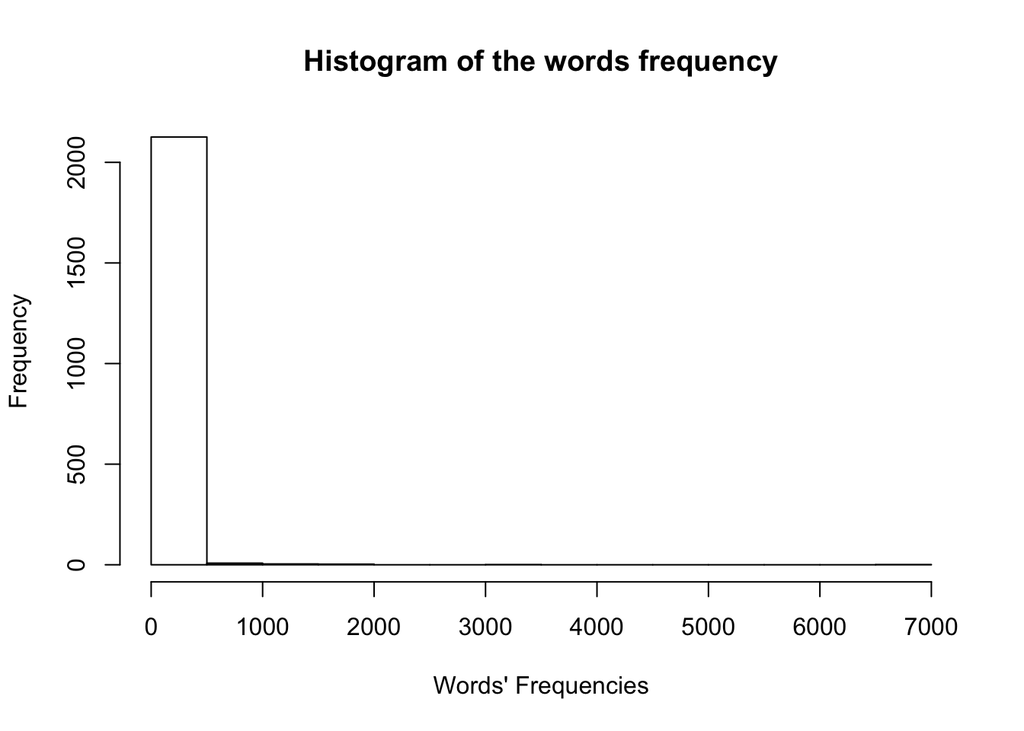

```r
# building a histogram for the frequencies of the different words after cleaned.

h = hist(fr.clean$freq, main = "Histogram of the words frequency", xlab = "Words' Frequencies")
```

## Sentimental analysis

In this part of the report I use the function sentimentalTabel() to analyze the sentiment of the tweets collected. Since I acquired a large number of tweets, the sentimental analysis of the dataset I have should reflect the population’s.

It is clear that most of the tweets about Airbnb are positive, which indicates satisfaction of the services they provide.

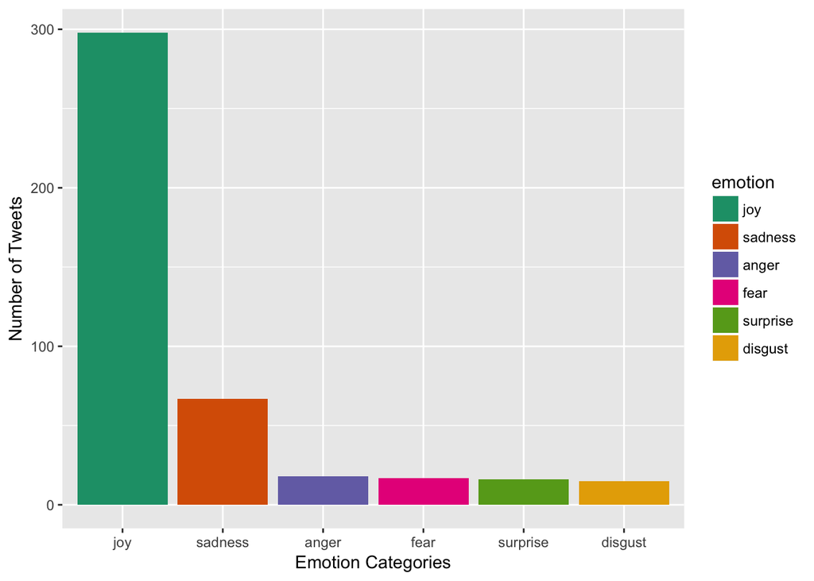

```r
    #SENTIMENTAL ANALYSIS
    sentimentalTable <- function(twts_txt){

      twts_class_emo = classify_emotion(twts_txt, algorithm="bayes", prior=1.0)
      emotion = twts_class_emo[,7]
      emotion[is.na(emotion)] = "unknown"

      twts_class_pol = classify_polarity(twts_txt, algorithm="bayes")
      polarity = twts_class_pol[,4]

      sentiment_dataframe = data.frame(text=twts_txt, emotion=emotion, polarity=polarity, stringsAsFactors=FALSE)
      sentiment_dataframe = within(sentiment_dataframe, emotion <-
                                     factor(emotion, levels=names(sort(table(emotion), decreasing=TRUE))))

      sentiment_dataframe = sentiment_dataframe[sentiment_dataframe$emotion!= "unknown", ]# removing the rows with an unknown emotion.
    ggplot(sentiment_dataframe, aes(x=polarity)) +
                  geom_bar(aes(y=..count.., fill=polarity)) +
                  scale_fill_brewer(palette="RdGy") +
                  theme(legend.position="right") + ylab("Number of Tweets") + xlab("Polarity Categories")

    ggplot(sentiment_dataframe, aes(x=emotion)) + geom_bar(aes(y=..count.., fill=emotion)) +
                  scale_fill_brewer(palette="Dark2") +
                  theme(legend.position="right") + ylab("Number of Tweets") + xlab("Emotion Categories")

}

# takes a dataframe of tweet objects then extracts and cleans text
CleanTweets <- function(df) {
  # extract text
  clean_text = df$text

  #removes emoticons #ref: (Hicks , 2014)
  clean_text <- sapply(clean_text,function(row) iconv(row, "latin1", "ASCII", sub=""))
  clean_text = gsub("&amp", "", clean_text)       # & sign
  clean_text = gsub("(RT|via)((?:\\b\\W*@\\w+)+)", "", clean_text)  #retweets
  clean_text = gsub("@\\w+", "", clean_text)        # @'s
  clean_text = gsub("[[:punct:]]", "", clean_text)  # punctuation
  clean_text = gsub("[[:digit:]]", "", clean_text)  # digits
  clean_text = gsub("http\\w+", "", clean_text)     # urls
  clean_text = gsub("[ \t]{2,}", "", clean_text)    # brakets curly and sq
  clean_text = gsub("^\\s+|\\s+$", "", clean_text)  # spaces

  # remove common words
  # collected common words in english
  common_words <- c('the', 'and', 'that', 'not', 'you', 'this', 'but',
                    'his', 'they', 'her', 'she', 'will', 'one', 'all',
                    'would', 'there', 'the', 'for', 'with', 'from',
                    'about', 'into', 'over', 'after')
  for (word in common_words) {
    clean_text = gsub(word, "", clean_text)
  }

  # also the search term!
  clean_text = gsub(tolower(BRAND), "", clean_text)
  clean_text = gsub(capitalize(BRAND), "", clean_text)

  return (clean_text)
}

sentimentalTable(CleanTweets(df_tweets))
```

## Bar charts

The following bar chart represents the classification of the tweet from the perspective of it being a retweet.

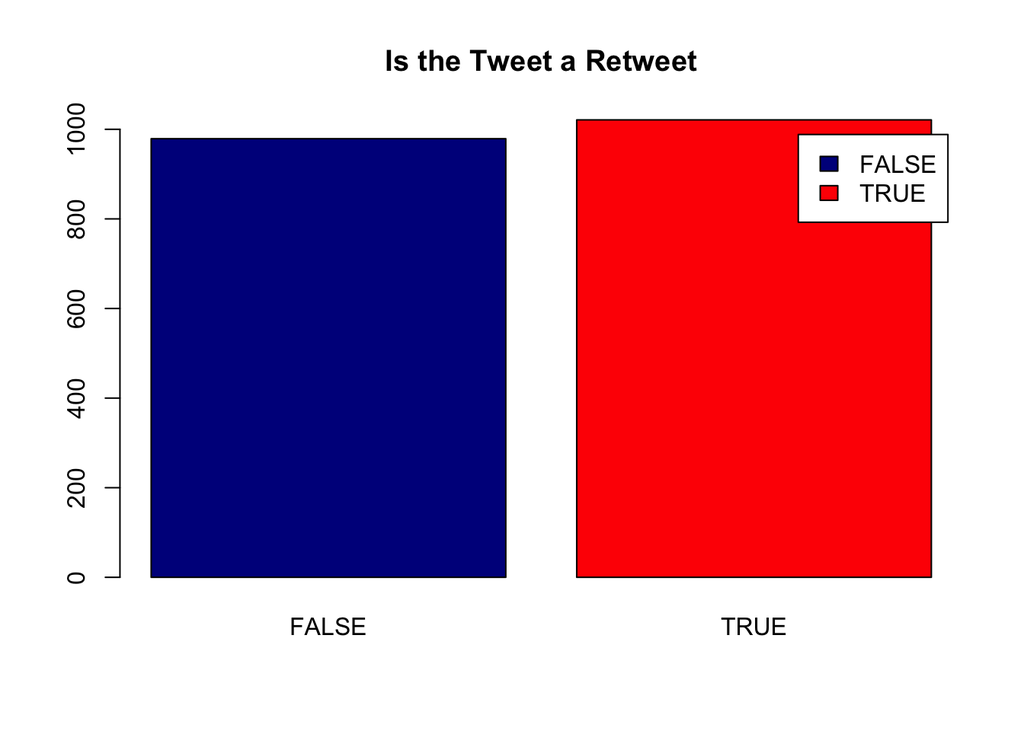

```r
# Grouped Bar Plot ( to measure if the tweet was a retweet)

counts <- table(df_tweets.1$isRetweet)
barplot(counts, main="Is the Tweet a Retweet"
        , col=c("darkblue","red"),
        legend = rownames(counts), beside=TRUE)
```

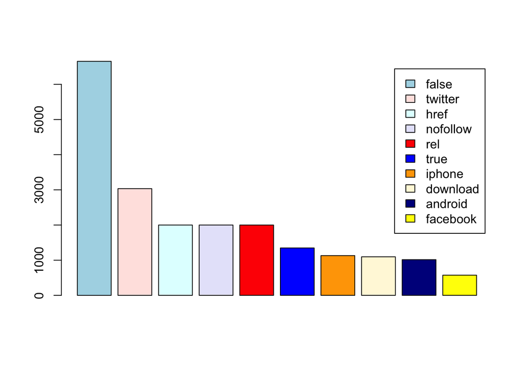

```r
# # constructing a pie chart with the words that are associated with the brand

fr.clean.head = head(fr.clean,10)
bar.clean = barplot(as.numeric(fr.clean.head$freq), col = c("lightblue", "mistyrose",
                "lightcyan", "lavender", "red", "blue", "orange", "cornsilk","darkblue","yellow" ),
                    legend = rownames(fr.clean.head))
```

## Probability Equation

I constructed an equation that measure the probability of any word to be associated with the Brand depending on the sample of the tweets I have Acquired, using an if statement. For example, I used the word Canada and the following is the probability that the word Canada is associated with the Airbnb.

```r
y = "canada"# enter the word you want to test other than the brands name.

# the if statement make sure that the word is already used otherwise it returns the value 0
if (y %in% fr.clean$word) {

  u = fr.clean[which(fr.clean$word == y),]
  num = as.numeric(u$freq)
  p = (num/sum(as.numeric(fr.clean$freq)))*100

}else{
  p = 0
}
# p is the probability that the word y is used in the same tweet the BRAND is mentioned.
p
```

```
## [1] 0.005115744
```

# The Map

Here I used the package leaflet to construct a map that shows the location of the geocoded tweets. From the map it seems that most of Airbnb services are available in North America. However, I cannot infer that this is always true because of the small sample of geocoded tweets available.

```r
# m is the map
# creating the base for m
m <- leaflet(map) %>% addTiles()

#adding the locations of the tweets.
m %>% addCircles(map, lng = as.numeric(df_tweets.map$longitude), lat = as.numeric(df_tweets.map$latitude), popup = NULL,
                 weight = 8, radius = 40, color = "#fb3004", stroke = TRUE, fillOpacity = 0.8)
```

[interactive chart not shown]